# The data-manager warehouse

Raw & derived tables · SF1 reference · PIT universe · tear sheets & dead-stock exhibit

Author

data-manager project

Published

August 12, 2026

**Abstract.** `~/.prime/agent/data_manager.db` is the single local SQLite source of point-in-time market data for the quant stack: **61.7M as-traded daily price rows** (stocks and funds) back to 1998, a **3.15M-row SF1 fundamentals mirror** in all six reporting dimensions, the full Sharadar securities master (31,742 instruments, survivorship-free), corporate actions (670k rows incl. delistings), and a locally **derived** point-in-time investable universe (`universe_pit`, 13.5M stock-days across 7,187 trading days). This report separates the **raw Sharadar bulk tables** from the **locally derived** ones, documents every SF1 column and reporting dimension, dissects the PIT universe (market-cap bins, sector and industry coverage), gives tear sheets for a mega / mid / small cap plus a **dead-stock exhibit** (Lehman Brothers), and reports freshness and data-quality findings. Numbers are as of the 2026-08-11 warehouse build; the PIT universe was rebuilt 2026-08-12 after a profile-carriage bug fix (see §6).

# 1 Warehouse at a glance

|  | table | origin | rows | first | last |
| --- | --- | --- | --- | --- | --- |
| 0 | prices | RAW (bulk) | 61,738,493 | 1997-12-31 | 2026-08-11 |
| 1 | sf1 | RAW (bulk) | 3,147,339 | 1990-06-06 | 2026-08-10 |
| 2 | fundamentals | DERIVED | 173,132 | 1992 | 2026 |
| 3 | quarterly_statements | DERIVED | 653,429 | 1992-12-31 | 2026-07-05 |
| 4 | ratios | DERIVED | 17,668 | 2026-08-12 | 2026-08-12 |
| 5 | metrics | RAW (bulk) | 31,744 | 1997-12-31 | 2026-08-11 |
| 6 | securities_master | RAW (bulk) | 31,742 | — | — |
| 7 | corporate_actions | RAW (bulk) | 670,752 | 1997-12-31 | 2026-08-13 |
| 8 | sp500_membership | RAW (API) | 59,627 | 1957-03-04 | 2026-08-10 |
| 9 | universe_pit | DERIVED | 13,459,809 | 1998-01-14 | 2026-08-11 |

One file, **13.7 GB**, WAL mode. `RAW (bulk)` tables are loaded verbatim from Sharadar bulk-download zips (~2 GB, full history, zero per-ticker API calls); `DERIVED` tables are rebuilt locally with zero remote requests; `sp500_membership` comes from the Sharadar API (whole table). §2 defines each table’s lineage precisely.

**Purpose-built indexes:** prices.idx_prices_date; prices.idx_prices_ticker; sf1.idx_sf1_ticker_dim; universe_pit.idx_pit_asof.

# 2 Raw Sharadar tables vs locally derived tables

The dataset is split by *lineage*, not by name. The four raw families come from executable bulk zips (`.csv.zip`), always fetchable again; every derived table can be wiped and rebuilt with a single CLI command and **no market-data requests**.

|  | table | source | notes |
| --- | --- | --- | --- |
| 0 | securities_master | tickers zip (SEP stocks + SFP funds) | whole Sharadar tickers table; every instrument incl. 19,227 delisted; `table` column marks the source zip (stocks=21,960 / funds=9,782) |
| 1 | corporate_actions | actions zip | splits, dividends, listed, delisted, ticker changes, spinoffs, bankruptcies (672k rows; 14× the API's 47k) |
| 2 | metrics | metrics zip | latest + multi-date snapshot metrics: price, betas (1y/5y), MA50/200, 52w hi/lo, returns 1y/5y/YTD, volumes, dividend yields |
| 3 | sf1 | fundamentals zip | 112 fields × 6 reporting dimensions (ARQ/ARY/ART/MRQ/MRY/MRT); all 112 fields stored as native columns; §5 + appendix is the reference |
| 4 | prices | stocks zip + funds zip | as-traded OHLCV + total-return factor. Bulk columns are split-adjusted; the loader stores as-traded (close=closeunadj, OHLC × closeunadj/close) and adjustment=closeadj/closeunadj |
| 5 | sp500_membership | Sharadar API (whole table) | S&P500 membership history 1957 → now with add/drop actions (59.6k rows) |
| 6 | french_factors | Ken French Data Library (daily factor zips) | Fama/French daily factor returns: Mkt-RF, SMB, HML, RMW, CMA, Mom, ST_Rev, LT_Rev, RF — percent/day, 1926-01-26 → now (26,403 rows); §13; the one non-Sharadar raw table |

[output not shown]

**Rebuild map** (all local, no API): `build-piotroski` / `build-quarterly` / `build-ratios` / `build-universe-pit [--history]` under `data-manager`; a from-zero warehouse rebuild is `bulk-fromzero` (downloads the zips once, loads, derives, builds PIT, optimizes).

**The `prices.adjustment` contract.** `adjustment` satisfies $P^{\mathrm{adj}}_t = P^{\mathrm{as\text{-}traded}}_t \times \mathrm{adjustment}_t$ where $P^{\mathrm{adj}}$ is the split- *and* dividend-adjusted close (Sharadar `closeadj`). The as-traded OHLC stored in the table is recovered from the bulk file by scaling the split-adjusted OHLC with the same-row split factor `closeunadj/close`; therefore **`close` is the true as-traded price** (it gaps at stock splits — see NVDA 2024-06-10 in §7) **and the adjustment factor only matters for total-return series** (§10 quantifies the no-trade and adjustment-tail rows).

## 2.1 Column-level data dictionary

Sharadar ships the field definitions themselves as a downloadable dataset — the **`descriptions` table** (one row per table + field: `table`, `indicator`, `isfilter`, `isprimarykey`, `title`, `description`, `unittype`; 373 rows covering all 17 vendor datasets). This warehouse now stores it as the live `descriptions` table, loaded from the bulk pipeline like any other raw table and refreshed with every `bulk_update` — so the dictionary in the database is the vendor’s own, versioned with each pull.

|  | vendor_table | fields |
| --- | --- | --- |
| 0 | SF1 | 112 |
| 1 | EVENTCODES | 37 |
| 2 | SF3A | 29 |
| 3 | SF3B | 28 |
| 4 | TICKERS | 28 |
| 5 | SF2 | 24 |
| 6 | METRICS | 22 |
| 7 | ACTIONTYPES | 19 |
| 8 | TABLE-DESCRIPTIONS | 14 |
| 9 | DAILY | 10 |
| 10 | SEP | 10 |
| 11 | SFP | 10 |
| 12 | french_factors | 10 |
| 13 | ACTIONS | 7 |
| 14 | INDICATORS | 7 |
| 15 | SP500 | 7 |
| 16 | SF3 | 6 |
| 17 | EVENTS | 3 |

Every dictionary row carries a full sentence-level definition — e.g.:

|  | table_name | indicator | title | description |
| --- | --- | --- | --- | --- |
| 0 | SF1 | revenue | Revenues | [Income Statement] The amount of Revenue recognised from goods sold; services rendered; insurance premiums; or other activities that constitute an ear |

| our table | vendor dictionary source | our table | vendor dictionary source |
| --- | --- | --- | --- |
| `securities_master` | TICKERS | `fundamentals` (derived) | this repo |
| `corporate_actions` | ACTIONS | `quarterly_statements` (derived) | this repo |
| `sp500_membership` | SP500 | `ratios` (derived) | this repo |
| `metrics` | METRICS (19 of 22 stored) | `universe_pit` (derived) | this repo |
| `sf1` | SF1 (all 112 fields as native columns) | `classifications`, `universe` | this repo |
| `prices` | SEP/SFP bulk price columns | `snapshots` (ledger) | this repo |
| `french_factors` | Fama/French factors (Ken French Data Library; defs written by its loader) | `universe` (derived) | this repo |

The full column-level dictionary for all 15 tables — vendor definitions *and* the derived-table semantics written from this repo’s code — is in **`docs/data_dictionary.md`** (+ machine-readable `docs/data_dictionary.json`), generated from the in-DB `descriptions` table. The SF1 appendix in this report shows the same 112-field dictionary grouped by family. Vendor datasets we do **not** store: `SF2` (insider holdings), `SF3/SF3A/SF3B` (institutional investors), `EVENTS`/`EVENTCODES` (material events), `DAILY` (daily mcap/EV/PE metrics — not the OHLC table), and the meta-tables `INDICATORS`, `ACTIONTYPES`, `TABLE-DESCRIPTIONS` (all still present inside `descriptions` if ever needed).

# 3 Securities master & corporate actions

The two “who and what happened” tables. Both are raw Sharadar bulk files (`tickers` zip and `actions` zip), and both are survivorship-free — a name that delisted in 2008 keeps its row and its complete event history, which is exactly what the PIT universe and the dead-stock exhibit rely on.

## 3.1 The securities master (`securities_master`, 31,742 rows)

One row per instrument — US-listed stocks, ADRs, preferred, warrants, and funds — the vendor’s universe cube. The primary key is **`permaticker`** (the vendor’s stable internal id); `ticker` is the instrument’s **current / last symbol**. This matters: Lehman’s master row is `LEHMQ`, not `LEH` — the historical symbols live only in `corporate_actions` ticker-change rows, so never assume `ticker` was valid throughout the price history.

|  | kind | instruments | delisted | first | last |
| --- | --- | --- | --- | --- | --- |
| 0 | funds | 9782 | 3588 | 1986-01-01 | 2026-08-11 |
| 1 | stocks | 21960 | 15639 | 1986-01-01 | 2026-08-11 |

|  | field | value |
| --- | --- | --- |
| 0 | ticker | AAPL |
| 1 | name | APPLE INC |
| 2 | exchange | NASDAQ |
| 3 | isdelisted | N |
| 4 | category | Domestic Common Stock |
| 5 | cusips | 037833100 |
| 6 | sector | Technology |
| 7 | industry | Consumer Electronics |
| 8 | sicsector | Manufacturing |
| 9 | sicindustry | Electronic Computers |
| 10 | famaindustry | Computers |
| 11 | currency | USD |
| 12 | location | California; U.S.A |
| 13 | firstpricedate | 1986-01-01 |
| 14 | lastpricedate | 2026-08-11 |
| 15 | table | stocks |

Key columns (AAPL above is a live example):

| column | meaning |
| --- | --- |
| `permaticker` / `ticker` | stable id / current-last symbol (master PK is permaticker) |
| `name`, `exchange` | legal name; NASDAQ/NYSE/NYSEMKT/… (`securities_master.exchange`, not the price source) |
| `isdelisted` | `Y`/`N` — full-table flag; `Y` for 19,227 rows (15,639 stocks + 3,588 funds), matching the 19,227 `delisted` action rows 1:1 |
| `category` | instrument class: Domestic Common Stock (+ Primary/Second class), ADR, preferred, warrant, Canadian … — one of the inputs to PIT membership |
| `sector` / `industry` | Sharadar’s own taxonomy (e.g. Technology / Consumer Electronics) — **full-coverage** classification of ~99.4% of stocks; do not confuse with the GICS labels in `classifications` (§9) |
| `sicsector` / `sicindustry`, `famaindustry` | two further taxonomies on the same row (SIC-based; Fama-French 12/48) |
| `scalemarketcap` / `scalerevenue` | vendor size-class labels (1–Nano … 6–Mega) for snapshot mcap/revenue |
| `cusips`, `figi`, `currency`, `location` | identifiers and domicile (currency is usually USD; ADRs included) |
| `firstpricedate` / `lastpricedate` | price-history bounds in `prices` — the delisting date for dead names (LEHMQ: 2008-10-15) |
| `firstquarter` / `lastquarter` | SF1 coverage bounds (AAPL 1992-12-31 → 2026-06-30) |
| `table` | source zip: `stocks` = 21,960 / `funds` = 9,782 (funds are reference series only) |

|  | exchange | stocks |
| --- | --- | --- |
| 0 | NASDAQ | 13859 |
| 1 | NYSE | 6807 |
| 2 | NYSEMKT | 1275 |
| 3 | NYSEARCA | 9 |
| 4 | BATS | 6 |
| 5 | OTC | 4 |

## 3.2 Corporate actions (`corporate_actions`, 670,752 rows)

|  | action | n | tickers |
| --- | --- | --- | --- |
| 0 | dividend | 550059 | 13524 |
| 1 | listed | 23357 | 23357 |
| 2 | delisted | 19227 | 19227 |
| 3 | tickerchangeto | 13451 | 10266 |
| 4 | tickerchangefrom | 13451 | 10266 |
| 5 | split | 12923 | 7109 |
| 6 | initiated | 8407 | 8407 |
| 7 | relation | 7872 | 6620 |
| 8 | acquisitionof | 7594 | 2743 |
| 9 | acquisitionby | 7514 | 7514 |
| 10 | bankruptcyliquidation | 3348 | 3348 |
| 11 | regulatorydelisting | 887 | 887 |
| 12 | spinoff | 556 | 439 |
| 13 | spunofffrom | 555 | 550 |
| 14 | spinoffdividend | 519 | 409 |
| 15 | adrratiosplit | 386 | 252 |
| 16 | voluntarydelisting | 378 | 378 |
| 17 | mergerto | 134 | 134 |
| 18 | mergerfrom | 134 | 114 |

[output not shown]

|  | ticker | date | action | value | contraticker |
| --- | --- | --- | --- | --- | --- |
| 0 | ^VIX | 1997-12-31 | initiated |  | ^VIX |
| 1 | MTCH | 2005-08-09 | spinoff | 1.0 | EXPE |
| 2 | MTCH | 2008-08-20 | spinoff | 0.03333 | TREE |
| 3 | MTCH | 2008-08-20 | spinoff | 0.2 | HSNI |
| 4 | LEHMQ | 2008-10-15 | bankruptcyliquidation | 55.6 | N/A |
| 5 | LEHMQ | 2008-10-15 | delisted | 55.6 | N/A |
| 6 | LEHMQ | 2008-10-15 | tickerchangefrom |  | LEH |
| 7 | LEHMQ | 2008-10-15 | tickerchangeto |  | LEHMQ |
| 8 | MTCH | 2015-11-19 | spinoff | 0.0 | MTCH2 |
| 9 | MTCH | 2020-07-01 | spinoff | 2.0 | PPLI |
| 10 | NVDA | 2021-07-20 | split | 4.0 | N/A |
| 11 | NVDA | 2024-06-10 | split | 10.0 | N/A |

**Semantics worth knowing.** (1) `date` is the *effective* date — ex-date for dividends, split-date for splits — and it is the same date the price series moves on, so the rows pair 1:1 with the steps of the `adjustment` chain (§4). (2) `value` has **no single unit**: split ratio and `$`/share for dividends are clean and verified; `spinoff` value is shares per original share; `tickerchangeto/from` and `relation` put the counterparty in the contra columns; for `delisted`/`acquisitionof` rows, `value` is a vendor context number (delisting consideration in vendor units — *not* the last trade price, which lives in `prices` / `master.lastpricedate`), so verify before using it numerically. (3) Contra columns are `N/A` unless the event is paired. (4) The action ledger is *not* truncated per instrument: it is the complete hand-maintained vendor history, which is what makes it trustworthy evidence for delisting and bankruptcy questions (the LEHMQ exhibit in §8 is built straight off these rows).

# 4 Price coverage & depth

Daily as-traded OHLCV, survivorship-free (delisted names stay in the table). The stocks-vs-funds split uses the bulk-file origin (`securities_master.table`).

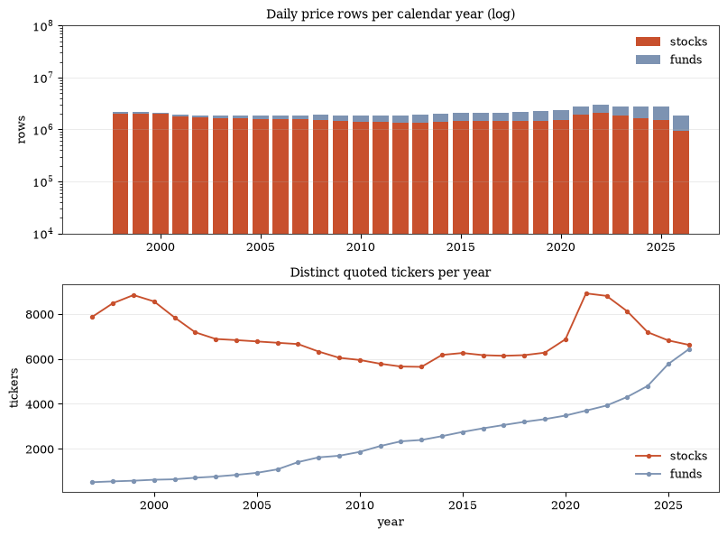

## 4.1 The adjustment factor — what `adjustment` is, precisely

Every `prices` row carries `adjustment`, and the tear sheets plot “as-traded close” against “adjusted close (= close × adjustment)”. Behind that one multiplication sits the whole history of the stock’s corporate actions, collapsed into a single cumulative number per day.

**Construction.** `adjustment(t) = closeadj(t) / close(t)` where `close` is the as-traded close and `closeadj` is the vendor’s total-return-adjusted close (normalized so the factor is exactly 1.0 on the latest quote). The adjusted series is built one event at a time — each event *multiplies every price before it* by a factor:

| event | per-event factor applied to earlier prices |
| --- | --- |
| stock split `s:1` (e.g. 4:1) | `1/s` (prices before the split shrink by 4×, so they stay comparable with post-split prices) |
| cash dividend `d` on the ex-date | `≈ 1 − d/c` with `c` the price level at the ex-date (the dividend is “reinvested” into the series) |

Because the factors *multiply*, the chains telescope: the factor on a given day is just **the product of the per-event factors of every event that happens after it** — the same collapsed product for every day in an interval between two events. One number per day is therefore the *whole* chain, not a simplification:

```
adjustment(t)  =  Π  over events E with E.date > t   of  factor(E)      (up to vendor file precision)
```

**Verified against the raw ledger.** Rebuilding the chain from scratch — multiplying the measured per-event steps (split factors and dividend steps from `corporate_actions`, `1 − d/c` from `prices`) backwards from the latest day, exactly reproduces the stored column: e.g. NVDA 2026-03-10 stored `0.9988039` vs reconstructed `0.9988027`; NVDA 2021-07-19 stored `0.0249151` vs `0.0249120`. The ~1e-4 relative gap on old rows is the vendor file’s own decimal rounding, not a semantic difference.

|  | ticker | event | date | stored step | expected | meaning |
| --- | --- | --- | --- | --- | --- | --- |
| 0 | NVDA | 4:1 split | 2021-07-20 | 0.249998 | 1/4 | adj. series −0.9% overnight (true return; raw was −75%) |
| 1 | NVDA | 10:1 split | 2024-06-10 | 0.100000 | 1/10 | adj. series +0.7% (true return; raw was −90%) |
| 2 | NVDA | 3:2 split | 2007-09-11 | 0.666229 | 2/3 | odd ratios handled the same way |
| 3 | AAPL | 4:1 split | 2020-08-31 | 0.250000 | 1/4 | adj. series +3.4% overnight |
| 4 | AAPL | 7:1 split | 2014-06-09 | 0.142852 | 1/7 | adj. series +1.6% overnight |
| 5 | C | 1-for-10 reverse | 2011-05-09 | 10.000000 | 10 | reverse splits handled identically (factor > 1) |
| 6 | NVDA | $0.25 dividend | 2026-06-04 | 0.998859 | 1−d/c | adj.-close return across the ex-date 218.66/(214.75·0.998859) = 1.0194 = (218.66+0.25)/214.75 — the dividend is inside the series |

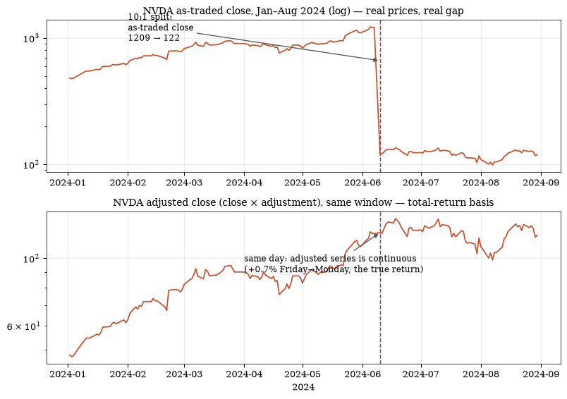

## 4.2 The look-ahead question — is `adjustment` safe for PIT backtests?

This is the subsection that matters most if you trade on this data. The “embeds future events” warning is precise in a way that admits an exact remedy — here is the whole argument, slowly, then the fix.

**Step 1 — where the future lives.** Restate the construction: `adjustment(t)` is the product of the factors of *every* corporate action after `t`, anchored so the latest quote has factor 1.0. So the factor on a 2021 date *contains* the 2024 split:

```
adjustment(NVDA, 2021-07-19) = 0.024915
   =  (dividend factors 2021→2026) × [10:1 split 2024] × [4:1 split 2021]
```

Nothing about that is wrong for *returns* — the chain is exactly what makes a long-horizon adjusted return equal the total return. But the **level** (literal adjusted price) at `t` was set partly by events that nobody knew on date `t`. A strategy deciding on date `D` may only use facts known by `D`; the stored level at `t < D` uses facts from after `D`. That is the look-ahead.

**Step 2 — what actually cancels.** Take the true as-of-`D` factor (events known by `D` only):

```
A(t; D) = product of factors of events E with  t < E ≤ D      (known by D)
adj(t)  = product of factors of events E with  E > t          (stored)
```

Both include the same events in `(t, D]`. They differ only in events after `D` — and that difference is *one number for every t ≤ D*:

```
adj(t) = A(t; D) × adj(D)                       ← the key identity
```

Because the chains telescope, the unknown tail `Π_{E > D} factor(E)` is exactly the factor stored at the as-of date itself. Consequently:

| use of `adjustment` | PIT-safe? | remedy |
| --- | --- | --- |
| daily / multi-day **returns** (`adj(t2)/adj(t1) − 1`) | ✅ already safe — future factors cancel in the ratio; only events *inside* the window contribute | none |
| momentum / ratio signals between two past dates | ✅ same reason | none |
| **level** of a total-return series as of decision date `D` | ⚠️ scale includes events after `D` | rebase: `close(t) × adj(t) / adj(D)` |
| absolute **$ thresholds** on an adjusted level (e.g. “adjusted price < $5”) | ❌ never meaningful — the scale is total-return, not a price | use as-traded `close` (as `universe_pit` does) |
| cross-stock comparison of adjusted levels | ❌ levels are per-stock arbitrary scales | compare returns, never levels |

**Step 3 — the fix is one division, not a rebuild.** All the as-of-`D` information is already in the stored column. The point-in-time-correct total-return level at `t`, using only events known by `D`, is:

```
adjusted-PIT(t; D) = close(t) × adjustment(t) / adjustment(D)
```

|  | date | as-traded | stored adjusted level | PIT level as of 2021-07-19 |
| --- | --- | --- | --- | --- |
| 0 | 2020-12-03 | 535.84 | 13.34 | 535.54 |
| 1 | 2021-07-19 | 751.19 | 18.72 | 751.19 |

**Step 4 — what we actually do in the PIT backtests.** Three rules, no exceptions:

1. **Membership, screens, thresholds** — as-traded `close`, never adjusted. That is what `universe_pit` already does (as-traded close ≥ $2, as-traded $volume, quote ≤ 10 calendar days old, per-day “most recent valid quote” pointer — no post-hoc information anywhere in the membership).
2. **Signals and performance on returns** — use adjusted-close ratios (`adjusted_prices` without `asof`, or `close × adjustment` yourself). They are PIT-correct by the cancellation in Step 2; no rebuild, no backfill, no special handling around splits and dividend ex-dates.
3. **Anywhere a total-return LEVEL is needed as of a decision date `D`** (charts, TR indices, drawdown series, normalized relative strength) — rebase with `adjustment(D)`: `adjusted_prices(..., asof=D)` or the one SQL division above. Never mix levels across different as-of dates, and never compare adjusted levels across stocks.

The old advice — “rebuild adjustments only from events known by date D” — is still true, but it is now *exact and cheap*: the rebuild is a division by the factor already stored at `D`. Nothing in the warehouse needs a new column or a maintenance job for this.

# 5 SF1 fundamentals: columns and reporting dimensions

The SF1 mirror is the fundamentals backbone. **Every raw row carries all 112 vendor fields — 7 key/date fields + all 105 indicators — stored as native SQLite columns** (no blob, no decompression, no “important fields” ranking): this is a storage/query project, so the vendor schema is served as-is and every field is SQL-queryable (`WHERE`, `ORDER BY`, `GROUP BY` on any indicator). Reporting dimensions are the key to using the mirror without look-ahead bias.

## 5.1 Reporting dimensions: As-Reported vs Most-Recent-Reported

Sharadar delivers fundamentals in **six time dimensions** — two views × three periods. The naming is `AR` = **A**s-**R**eported, `MR` = **M**ost-**R**ecent (i.e. latest) **R**eported, with suffix `Y` annual, `Q` quarterly, `T` trailing twelve months (TTM):

| dimension | view | period | Sharadar definition (verbatim) |
| --- | --- | --- | --- |
| **ARQ** | As-Reported | quarterly | “As Reported view (AR) **excludes restatements**, point-in-time view with data time-indexed to the date the form 10 regulatory filing was submitted to the SEC … may include multiple observations in a … |
| **ARY** | As-Reported | annual | same AR semantics, annual observations |
| **ART** | As-Reported | TTM | same AR semantics, trailing-twelve-month observations |
| **MRQ** | Most-Recent-Reported | quarterly | “Most Recent Reported view (MR) **includes restatements**, time indexed to the financial/report period … presents the most recently reported data for that reporting period” — “typically suitable for a… |
| **MRY** | Most-Recent-Reported | annual | same MR semantics, annual observations |
| **MRT** | Most-Recent-Reported | TTM | same MR semantics, TTM observations |

**Practical rules.** Use **AR*** for point-in-time work (backtests, PIT screens) with the row’s `date` as the as-of availability date — `date <= D` is a valid point-in-time filter and is exactly what `universe_pit` does for shares. Use **MR*** for “what do we believe today” snapshots (`build-ratios` uses the latest `MRY` row). Restatements create AR-vs-MR splits on the same report period; when a company catches up after a reporting gap, ARQ may hold several filings for one quarter.

|  | dimension | rows | first calendar date | last calendar date |
| --- | --- | --- | --- | --- |
| 0 | ARQ | 654,535 | 1992-12-31 | 2026-06-30 |
| 1 | ART | 660,802 | 1992-12-31 | 2026-06-30 |
| 2 | ARY | 173,633 | 1992-12-31 | 2026-12-31 |
| 3 | MRQ | 717,906 | 1990-06-30 | 2026-06-30 |
| 4 | MRT | 736,956 | 1990-06-30 | 2026-06-30 |
| 5 | MRY | 203,507 | 1990-12-31 | 2026-12-31 |

## 5.2 Indicator dictionary: summary

There are **112 fields** (7 key/date fields + 105 indicators, all stored as native columns) grouped into five statement families. The **complete listing, every row shown**, is in the appendix:

[output not shown]

**Every field is a native column.** A first version of the loader ranked 29 “important” fields as columns and parked the other 76 in a compressed JSON `data` blob — that turned out to be the wrong call for a storage/query project: it encodes an opinion about which fields matter, it makes the other 76 fields invisible to SQL, and it is not even smaller on disk (blob ≈ 2.7 GB compressed vs ≈ 2.5 GB for the same fields as REAL columns; the 29-typed + blob split also stored those 29 fields twice). The warehouse now stores **all 112 fields as native columns** (2026-08-12 migration; DB 15.94 → 13.66 GB). Any indicator is queryable directly:

```sql
SELECT ticker, date, revenue, rnd, opex, cashneq
FROM   sf1
WHERE  ticker='AAPL' AND dimension='ARY'
ORDER  BY reportperiod DESC LIMIT 1;
```

The appendix below marks every indicator as a column.

Notes on semantics (verified from vendor docs + live rows):

- **Scale.** Every monetary field is raw as-reported units; the master’s `scalemarketcap` / `scalerevenue` columns are the Sharadar `10^scale` convention but the bulk file’s SF1 rows are already unscaled (AAPL 1999 `assets` = 5.44B exactly).
- **FX.** `*usd` fields are USD-normalized versions of the same line item (`revenueusd`, `ebitusd`, …); `fxusd` is the FX rate applied.
- **Shares.** `shareswa` (weighted avg) and `sharesbas` (basic) are used for PIT market cap in `universe_pit` (`price × shareswa`, ARQ/ARY ≤ date).
- **Valuation blanks.** `pe1`/`ps1` are forward-looking (next-period); SF1 does **not** carry `forward_pe` or `beta` → those stay NULL in `ratios` (documented limitation).
- **TTM.** `ART`/`MRT` rows exist (660k/737k) — TTM is a real dimension on the bulk file (the API serves 0 rows for it, another reason to use bulk).

# 6 PIT universe analysis

`universe_pit` is the locally derived investable universe — one row per (trading day, member) for **7,187 trading days (1998-01-14 → 2026-08-11)**. Algorithm (per ticker, no remote requests): walk its price rows keeping a rolling 20-session dollar-volume window and a pointer to the latest as-reported shares (SF1 ARQ/ARY `date ≤ row date`); a price row is *valid* when as-traded close ≥ $2, rolling avg $volume ≥ $5M with ≥ 10 sessions, and PIT mcap = close × shares ≥ $300M. Valid rows merge into runs that extend at most `max_quote_age` = 10 calendar days past the last fresh quote, then expand onto the global trading calendar.

**2026-08-12 fix (important).** The original build stored the *run-start* quote’s price/mcap/dvol for the whole run — a continuously trading name has one run from 1998 to today, so AAPL carried **$19.75 (1998) as its 2026 profile**. Membership dates were correct; the attached profile was not. Rebuilt so each member day carries the **most recent valid quote ≤ that day** (regression-tested; tests/test_db.py). All PIT numbers in this section use the rebuilt table.

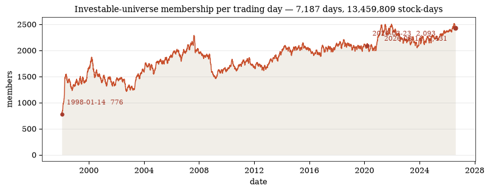

Membership grows from **776 names (1998-01-14)** to **2,431 (2026-08-11)**; the 2020 crash bottom holds 2,093 members (2020-03-23). The chart’s plateau-and-step shape reflects listing standards (more names pass the $5M-dollar-volume screen over time) rather than definition changes; the full range is re-runnable via `build-universe-pit --history` with different thresholds.

## 6.1 Market-cap coverage on the latest day

|  | market-cap bin | members | share of names | mcap ($B) | share of mcap |
| --- | --- | --- | --- | --- | --- |
| 0 | $300M–1B (small) | 380 | 15.6% | $249B | 0.3% |
| 1 | $1–5B | 916 | 37.7% | $2,337B | 2.9% |
| 2 | $5–20B | 660 | 27.1% | $6,555B | 8.1% |
| 3 | $20–100B | 349 | 14.4% | $15,785B | 19.4% |
| 4 | $100B+ (mega) | 126 | 5.2% | $56,264B | 69.3% |

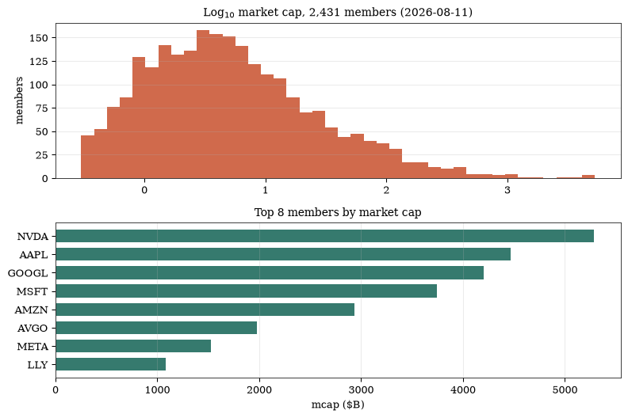

|  | min mcap threshold | members kept | share of all members | total mcap of kept |
| --- | --- | --- | --- | --- |
| 0 | 0.3 | 2431 | 99.8% | $81,190T |
| 1 | 0.5 | 2329 | 95.6% | $81,150T |
| 2 | 1.0 | 2051 | 84.2% | $80,941T |
| 3 | 2.0 | 1681 | 69.0% | $80,402T |
| 4 | 5.0 | 1135 | 46.6% | $78,604T |
| 5 | 10.0 | 754 | 31.0% | $75,942T |
| 6 | 20.0 | 475 | 19.5% | $72,049T |
| 7 | 100.0 | 126 | 5.2% | $56,264T |

## 6.2 Sector and industry coverage (latest day)

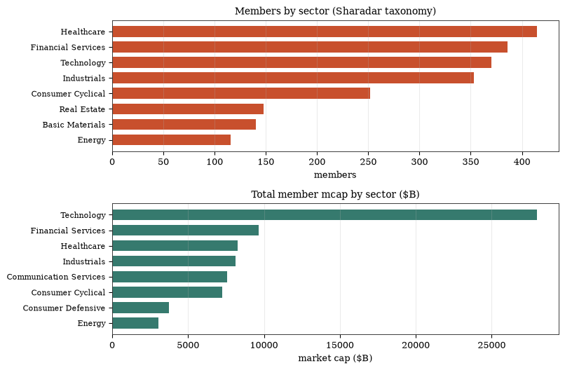

|  | industry | members | mcap ($B) |
| --- | --- | --- | --- |
| 0 | Biotechnology | 208 | $1,598B |
| 1 | Banks - Regional | 163 | $997B |
| 2 | Software - Application | 99 | $1,660B |
| 3 | Software - Infrastructure | 72 | $6,112B |
| 4 | Aerospace & Defense | 52 | $2,682B |
| 5 | Specialty Industrial Machinery | 51 | $1,059B |
| 6 | Asset Management | 46 | $995B |
| 7 | Medical Devices | 45 | $769B |
| 8 | Semiconductors | 42 | $10,755B |
| 9 | Capital Markets | 41 | $1,237B |
| 10 | Specialty Chemicals | 41 | $709B |
| 11 | Oil & Gas E&P | 39 | $627B |

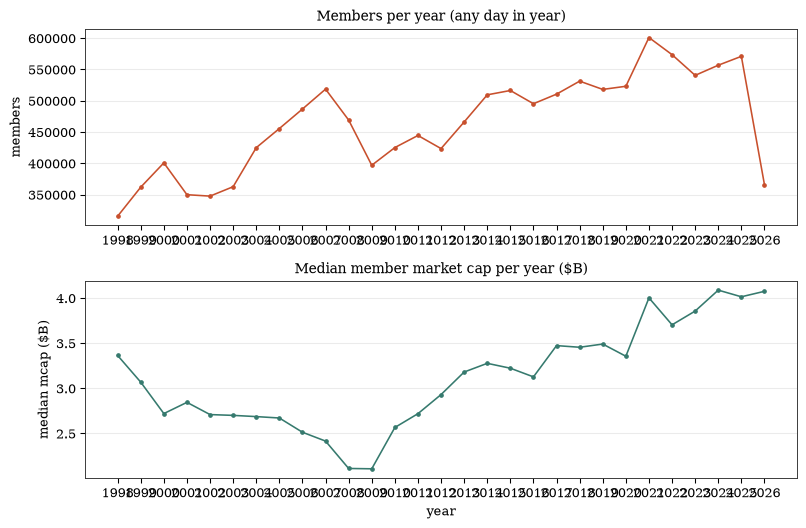

**Constitution (rebuilt, 7,187 days).** 1,955 of the 2,431 members on 2026-08-11 are plain Domestic Common Stock (the rest are Primary-class names); no ETF/ADR/preferred/warrant rows ever enter — the gate fails closed, per the positive inclusion-filter design. Exchange mix on the latest day: NYSE 1,252 / NASDAQ 1,155 / other 24.

# 7 Stock tear sheets

Picked on 2026-08-11: **NVDA** (mega, 28y history), **LVS** (mid, 22y), **STC** (small, 29y).

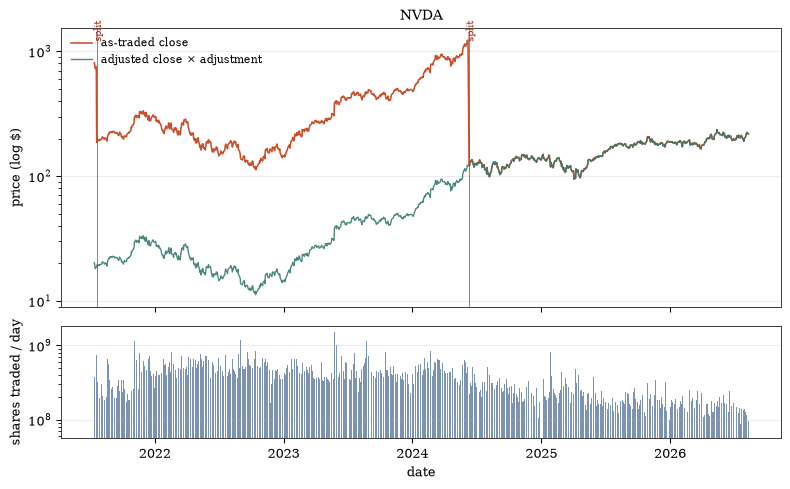

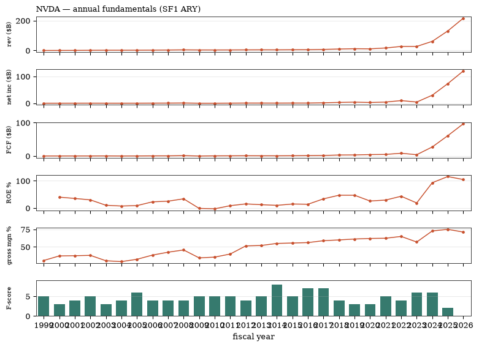

|  | metric | value |
| --- | --- | --- |
| 0 | name | NVIDIA CORP |
| 1 | status | active |
| 2 | sector / industry | Technology / Semiconductors |
| 3 | exchange | NASDAQ |
| 4 | last price | $217.50 |
| 5 | market cap | $5282.20B |
| 6 | avg 20d $vol | $26.0B |
| 7 | 52w low / high | $165.17 / $235.74 |
| 8 | return 1y | +19.5% |
| 9 | return 3y | -50.3% |
| 10 | return 5y | +9.3% |
| 11 | YTD | +15.2% |
| 12 | max drawdown (5y) | -92.3% |
| 13 | price history | 1999-01-22 -> 2026-08-11 |

|  | metric | value | period |
| --- | --- | --- | --- |
| 0 | revenue (FY) | $215.9B | (2026-FY) |
| 1 | net income (FY) | $120.1B | (2026-FY) |
| 2 | EBITDA (FY) | $144.6B | (2026-FY) |
| 3 | free cash flow (FY) | $96.7B | (2026-FY) |
| 4 | total assets | $206.8B | (2026-FY) |
| 5 | equity | $157.3B | (2026-FY) |
| 6 | shares (wtd avg) | 24,359,000,000 | (2026-FY) |
| 7 | EPS | 4.93 | (2026-FY) |
| 8 | ROE | 104.4% | (2026-FY) |
| 9 | ROA | 75.8% | (2026-FY) |
| 10 | ROIC | 119.7% | (2026-FY) |
| 11 | gross margin | 71.1% | (2026-FY) |
| 12 | net margin | 55.6% | (2026-FY) |
| 13 | P/E | 39.58 | (2026-FY) |
| 14 | P/B | 30.21 | (2026-FY) |
| 15 | P/S | 22.01 | (2026-FY) |
| 16 | EV | $4752.5B | (2026-FY) |
| 17 | div yield | 0.0% | (2026-FY) |

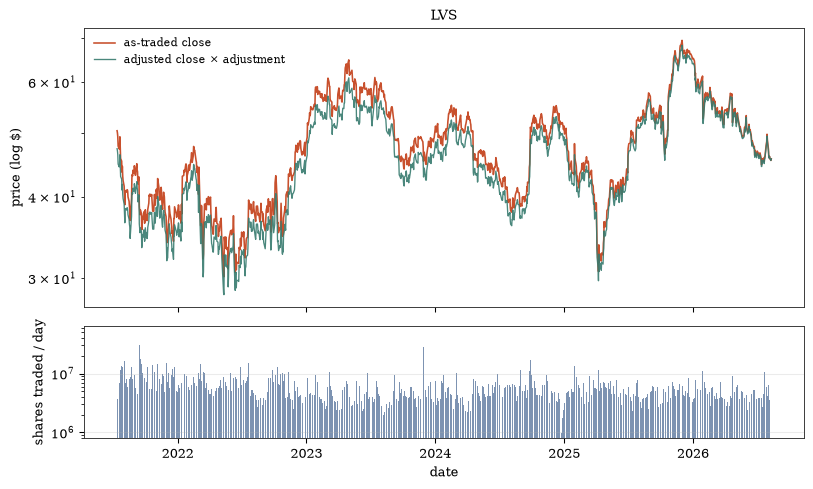

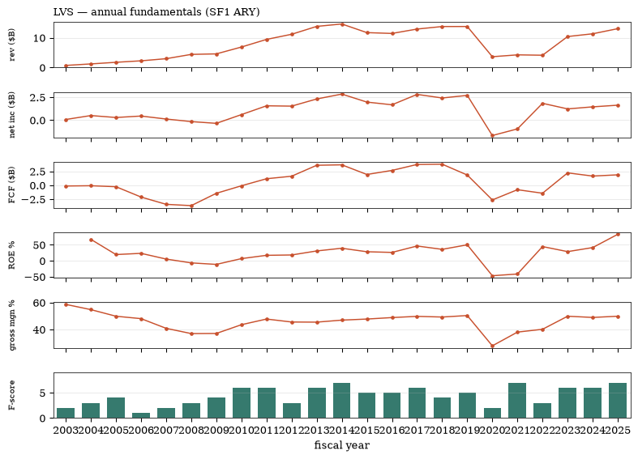

|  | metric | value |
| --- | --- | --- |
| 0 | name | LAS VEGAS SANDS CORP |
| 1 | status | active |
| 2 | sector / industry | Consumer Cyclical / Resorts & Casinos |
| 3 | exchange | NYSE |
| 4 | last price | $45.72 |
| 5 | market cap | $29.90B |
| 6 | avg 20d $vol | $235M |
| 7 | 52w low / high | $44.78 / $69.49 |
| 8 | return 1y | -13.8% |
| 9 | return 3y | -18.1% |
| 10 | return 5y | +12.1% |
| 11 | YTD | -29.9% |
| 12 | max drawdown (5y) | -52.7% |
| 13 | price history | 2004-12-15 -> 2026-08-11 |

|  | metric | value | period |
| --- | --- | --- | --- |
| 0 | revenue (FY) | $13.0B | (2025-FY) |
| 1 | net income (FY) | $1.6B | (2025-FY) |
| 2 | EBITDA (FY) | $4.2B | (2025-FY) |
| 3 | free cash flow (FY) | $1.9B | (2025-FY) |
| 4 | total assets | $21.9B | (2025-FY) |
| 5 | equity | $1.6B | (2025-FY) |
| 6 | shares (wtd avg) | 691,000,000 | (2025-FY) |
| 7 | EPS | 2.35 | (2025-FY) |
| 8 | ROE | 82.9% | (2025-FY) |
| 9 | ROA | 7.5% | (2025-FY) |
| 10 | ROIC | 9.7% | (2025-FY) |
| 11 | gross margin | 49.8% | (2025-FY) |
| 12 | net margin | 12.5% | (2025-FY) |
| 13 | P/E | 23.87 | (2025-FY) |
| 14 | P/B | 24.43 | (2025-FY) |
| 15 | P/S | 2.98 | (2025-FY) |
| 16 | EV | $50.7B | (2025-FY) |
| 17 | div yield | 1.7% | (2025-FY) |

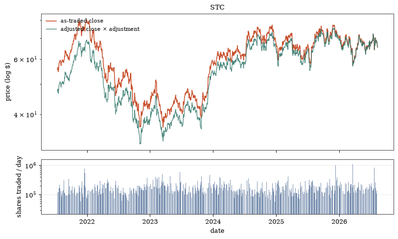

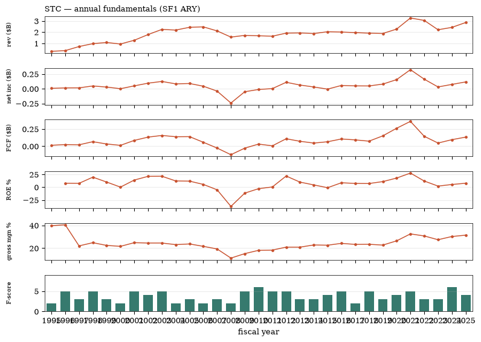

|  | metric | value |
| --- | --- | --- |
| 0 | name | STEWART INFORMATION SERVICES CORP |
| 1 | status | active |
| 2 | sector / industry | Financial Services / Insurance - Property & Casualty |
| 3 | exchange | NYSE |
| 4 | last price | $65.48 |
| 5 | market cap | $1.99B |
| 6 | avg 20d $vol | $14M |
| 7 | 52w low / high | $57.39 / $77.17 |
| 8 | return 1y | -3.6% |
| 9 | return 3y | +41.3% |
| 10 | return 5y | +9.6% |
| 11 | YTD | -6.4% |
| 12 | max drawdown (5y) | -54.6% |
| 13 | price history | 1997-12-31 -> 2026-08-11 |

|  | metric | value | period |
| --- | --- | --- | --- |
| 0 | revenue (FY) | $2.9B | (2025-FY) |
| 1 | net income (FY) | $116M | (2025-FY) |
| 2 | EBITDA (FY) | $232M | (2025-FY) |
| 3 | free cash flow (FY) | $132M | (2025-FY) |
| 4 | total assets | $3.3B | (2025-FY) |
| 5 | equity | $1.6B | (2025-FY) |
| 6 | shares (wtd avg) | 28,069,000 | (2025-FY) |
| 7 | EPS | 4.12 | (2025-FY) |
| 8 | ROE | 7.8% | (2025-FY) |
| 9 | ROA | 4.0% | (2025-FY) |
| 10 | ROIC | 8.7% | (2025-FY) |
| 11 | gross margin | 31.4% | (2025-FY) |
| 12 | net margin | 4.0% | (2025-FY) |
| 13 | P/E | 18.69 | (2025-FY) |
| 14 | P/B | 1.32 | (2025-FY) |
| 15 | P/S | 0.76 | (2025-FY) |
| 16 | EV | $2.6B | (2025-FY) |
| 17 | div yield | 2.9% | (2025-FY) |

# 8 Dead-stock exhibit: Lehman Brothers (LEHMQ)

|  | as_of | price | mcap ($B) | 20d avg $vol |
| --- | --- | --- | --- | --- |
| 0 | 2008-01-02 | $62.19 | 33.0B | 7.757826e+08 |
| 1 | 2008-06-02 | $33.83 | 18.7B | 8.596888e+08 |
| 2 | 2008-09-12 | $3.65 | 2.5B | 1.027161e+09 |
| 3 | 2008-09-22 | $3.65 | 2.5B | 1.027161e+09 |

|  | field | value |
| --- | --- | --- |
| 0 | ticker | LEHMQ |
| 1 | name | LEHMAN BROTHERS HOLDINGS INC |
| 2 | category | Domestic Common Stock |
| 3 | exchange | NYSE |
| 4 | delisted? | Y (delisted) |
| 5 | first priced | 1994-05-11 |
| 6 | last priced | 2008-10-15 |
| 7 | sector / industry | Financial Services / Capital Markets |
| 8 | permaticker | 188897 |

**Confirmed member of the PIT universe:** 2,689 trading days, 1998-01-14 → 2008-09-22. It was still a member on **2008-09-12** at $3.65 / $2.53B — the Friday before the 2008-09-15 bankruptcy filing — and membership ends 2008-09-22 (the 10-day quote-freshness expiry after NYSE halted trading). It never re-enters: delisted names fall out of the investable set exactly when they cease being investable, while prices, fundamentals, and actions are retained for research.

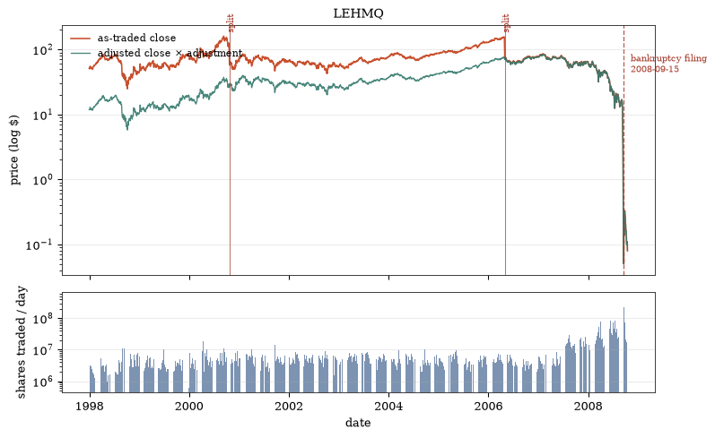

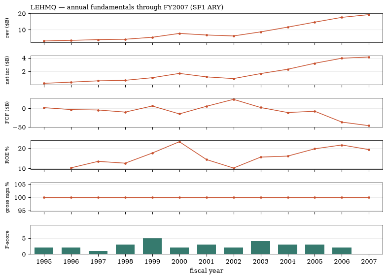

|  | date | action | name |
| --- | --- | --- | --- |
| 0 | 2008-02-29 | dividend | LEHMAN BROTHERS HOLDINGS INC |
| 1 | 2008-05-30 | dividend | LEHMAN BROTHERS HOLDINGS INC |
| 2 | 2008-10-15 | bankruptcyliquidation | LEHMAN BROTHERS HOLDINGS INC |
| 3 | 2008-10-15 | delisted | LEHMAN BROTHERS HOLDINGS INC |
| 4 | 2008-10-15 | tickerchangefrom | LEHMAN BROTHERS HOLDINGS INC |
| 5 | 2008-10-15 | tickerchangeto | LEHMAN BROTHERS HOLDINGS INC |

FY2007 (the last full year before the collapse) carries an **F-Score of 0** on the 9-point scale — the weakest possible signal — driven by negative CFO-vs-net-income accruals and deteriorating fundamentals across the board. FY2008 never appears in the as-reported (AR) view: the 10-K was never filed. The quarterly statement mirror runs through 2008-05-31 (51 quarters, 1995–2008).

# 9 GICS classification coverage

`classifications` carries the stock-universe gate: the eleven GICS labels mapped from Sharadar’s taxonomy. **Coverage is a known gap** — only the iShares-era universe (2,589 names) is classified, not the full 21,960-stock master; `securities_master.sector/industry` (Sharadar taxonomy) covers every instrument but uses non-GICS labels (e.g. *Healthcare* vs *Health Care*). The NOTES.md action item — a live GICS-map coverage check against the whole master — remains open.

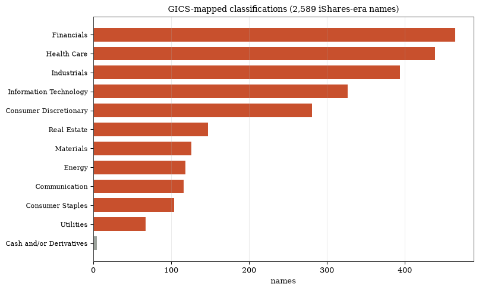

Classified names: **2,589** of **21,960** stocks in the master (**11.8%** coverage). No NULL sectors; the five *Cash and/or Derivatives* rows are iShares IWV placeholders that carry no GICS sector and are excluded from the stock allowlist by construction.

# 10 Freshness & data quality

|  | rows | % of total |
| --- | --- | --- |
| all rows | 61,738,493 | 100.00% |
| volume = 0 (no-trade days) | 3,398,664 | 5.50% |
| adjustment > 100 | 1,398,759 | 2.27% |
| adjustment < 0.01 | 28,052 | 0.05% |
| close ≤ 0 | 2 | 0.00% |
| volume = 0 AND adjustment > 100 (sentinel) | 301,299 | 0.49% |

|  | ticker | date | close | volume | adjustment |
| --- | --- | --- | --- | --- | --- |
| 0 | BINI | 2015-11-13 | 0.082 | 0 | 8.48e+18 |
| 1 | BINI | 2015-11-18 | 0.062 | 0 | 8.48e+18 |
| 2 | BINI | 2015-11-05 | 0.089 | 0 | 8.48e+18 |
| 3 | BINI | 2015-10-12 | 0.141 | 0 | 8.47e+18 |
| 4 | BINI | 2015-10-28 | 0.085 | 0 | 8.47e+18 |
| 5 | BINI | 2015-10-09 | 0.145 | 0 | 8.47e+18 |
| 6 | BINI | 2015-11-20 | 0.064 | 0 | 8.46e+18 |
| 7 | BINI | 2015-10-06 | 0.172 | 0 | 8.46e+18 |

|  | bucket | rows | last quote |
| --- | --- | --- | --- |
| 0 | funds | 15,475,363 | 2026-08-11 |
| 1 | stocks | 46,263,130 | 2026-08-11 |

|  | pulled_at | source | as_of | row_count |
| --- | --- | --- | --- | --- |
| 0 | 2026-08-12T21:17:22.705198 | french_factors | 2026-06-30 | 26403 |
| 1 | 2026-08-12T21:12:45.887489 | french_factors | 2026-06-30 | 26403 |
| 2 | 2026-08-11T21:35:26.626907 | ishares | ,"Aug 10, 2026 | 2592 |

# 11 Accessing the data (SQL & accessor API)

Two layers, both documented end-to-end in the repo’s **AGENTS.md** (the canonical guide for downstream consumers — this section is the short form).

## 11.1 The accessor functions (in this repo)

| function (module) | returns |
| --- | --- |
| `db.connect()` (`data_manager.db`) | a WAL-mode SQLite connection (tuned pragmas, schema ensured) — the normal entry for in-repo jobs |
| `universe.adjusted_prices(ticker, start=None, end=None)` | per-day dicts `date/open/high/low/close/volume/adjustment` **plus** `adjusted_open/.../adjusted_close` (= raw × adjustment); volume left as traded |
| `universe._hydrate_sf1(conn, ticker, dimension)` | full SF1 rows (all 112 fields, vendor-keyed incl. `datekey`) as dicts — no decompression needed |
| `universe.master_stocks(conn, isdelisted=None)` | all stock tickers (`table='stocks'`; honors DM_SHARD/DM_SHARDS) |
| `universe.universe_tickers(conn)` / `etfs.etf_tickers()` | universe / ETF manifest ticker lists |
| CLI `data-manager status` | live coverage snapshot |

There is no ORM: everything else is **plain SQL** over one of the connection entry points.

## 11.2 Plain SQL (read-only)

Outside this repo, prefer the read-only URI so nothing can ever be written:

```python
import sqlite3, pathlib
conn = sqlite3.connect(
    f"file:{pathlib.Path.home()}/.prime/agent/data_manager.db?mode=ro",
    uri=True)
conn.execute("PRAGMA cache_size=-65536"); conn.execute("PRAGMA mmap_size=134217728")
```

| task | SQL |
| --- | --- |
| daily bars / total returns | `SELECT date, close, volume, adjustment FROM prices WHERE ticker=? [AND date>=?]` and compute `close*adjustment` yourself; or `adjusted_prices` |
| cross-section on date D | `SELECT * FROM prices WHERE date=?` (uses `idx_prices_date`) |
| PIT shares / mcap | `SELECT shareswa FROM sf1 WHERE ticker=? AND dimension IN ('ARQ','ARY') AND date<=? ORDER BY date DESC LIMIT 1` |
| investable members on D | `SELECT * FROM universe_pit WHERE as_of=?` (uses `idx_pit_asof`) |
| fundamentals history | `SELECT * FROM sf1 WHERE ticker=? AND dimension='ARY' ORDER BY reportperiod` (all 112 fields are native columns) |
| delisting evidence | `corporate_actions` rows with `action IN ('delisted','bankruptcyliquidation')` |
| daily factor returns | `SELECT date, mkt_rf, smb, hml, rmw, cma, mom, st_rev, lt_rev, rf FROM french_factors WHERE date>=?` (percent/day) |

# 12 Database hygiene

The warehouse is refreshed by two commands, then verified:

1. **`uv run data-manager status`** — baseline row counts and the `snapshots` pull ledger.
2. **`uv run data-manager bulk-update`** — compares each table’s bulk zip against the server’s `modified` stamp (manifest in `~/.prime/agent/bulk/_manifest.json`), re-downloads only changed files, reloads those tables with `INSERT OR REPLACE` (prices full reload ≈ 12 min), re-derives piotroski / quarterly / ratios, and rebuilds `universe_pit --history` (≈ 12 min, 13.5M rows). Logs in `logs/`.
3. **`uv run data-manager optimize-db --backup <path>`** — consistent backup, WAL checkpoint, ANALYZE, `quick_check`, VACUUM (≈ 3 min; DB ≈ 16 GB). Run after every update; keep one backup per full rebuild.

**Cadence.** The Sharadar bulk zips refresh daily; a morning `bulk-update` + `optimize-db` keeps the warehouse current (worst case a few hundred MB–2 GB of downloads). `bulk-fromzero` is the full wipe-and-rebuild path (e.g., after a provider or schema change).

**Post-update verification checklist.**

|  | check | value |
| --- | --- | --- |
| 0 | prices last date | 2026-08-11 |
| 1 | universe_pit last as_of | 2026-08-11 |
| 2 | prices rows | 61738493 |
| 3 | universe_pit days | 7187 |
| 4 | AAPL 2026 close | 304.91 |
| 5 | AAPL pit profile 2026-08-11 | 304.91 |

Everything above works because the schema, indexes, and PRAGMAs are encoded in `db.connect()` (idempotent), and the full rebuild path (`bulk-fromzero`) already ends in `optimize-db`. The regression suite (`uv run pytest -q`, 96 tests) covers the PIT profile semantics, the `idx_prices_date` index, the French-factor loader semantics, and `optimize-db` itself.

# 13 Fama-French factor returns (`french_factors`)

The warehouse’s only **non-Sharadar raw table**: the Ken French Data Library’s five US **daily factor files** (mba.tuck.dartmouth.edu, free). One wide row per trading day — `date` (TEXT `YYYY-MM-DD`) is the primary key — holding the eight market factor series plus the daily risk-free rate, all in **percent per day** (0.09 = 0.09%) exactly as the site serves them. The vendor `-99.99` missing sentinel is stored NULL.

| factor | column | source file | first day |
| --- | --- | --- | --- |
| market excess return | `mkt_rf` | Fama/French 3 Factors | 1926-07-01 |
| size | `smb` | Fama/French 3 Factors | 1926-07-01 |
| value | `hml` | Fama/French 3 Factors | 1926-07-01 |
| profitability | `rmw` | Fama/French 5 Factors (2x3) | 1963-07-01 |
| investment | `cma` | Fama/French 5 Factors (2x3) | 1963-07-01 |
| momentum | `mom` | Momentum Factor | 1926-11-03 |
| short-term reversal | `st_rev` | Short-Term Reversal | 1926-01-26 |
| long-term reversal | `lt_rev` | Long-Term Reversal | 1930-03-20 |

`rf` is the daily risk-free rate (the simple daily rate that compounds to the 1-month T-bill); it is served by both the 3F and 5F files with identical values (verified on all 15,854 overlapping dates) and is stored once. The factors are value-weighted **long-short spreads** — market factor series, not tradable instruments, so never join them to `prices` by ticker.

## 13.1 Coverage and annualized means

|  | factor | rows | first | last | mean %/day | ann. mean % |
| --- | --- | --- | --- | --- | --- | --- |
| 0 | market (Mkt-RF) | 26274 | 1926-07-01 | 2026-06-30 | 0.0311 | 7.84 |
| 1 | size (SMB) | 26274 | 1926-07-01 | 2026-06-30 | 0.0050 | 1.26 |
| 2 | value (HML) | 26274 | 1926-07-01 | 2026-06-30 | 0.0152 | 3.82 |
| 3 | profitability (RMW) | 15854 | 1963-07-01 | 2026-06-30 | 0.0117 | 2.94 |
| 4 | investment (CMA) | 15854 | 1963-07-01 | 2026-06-30 | 0.0119 | 3.00 |
| 5 | momentum | 26173 | 1926-11-03 | 2026-06-30 | 0.0263 | 6.63 |
| 6 | ST reversal | 26403 | 1926-01-26 | 2026-06-30 | 0.2209 | 55.66 |
| 7 | LT reversal | 25173 | 1930-03-20 | 2026-06-30 | 0.0055 | 1.38 |
| 8 | risk-free (RF) | 26274 | 1926-07-01 | 2026-06-30 | 0.0119 | 3.01 |

The non-NULL row counts are exactly the five vendor files’ sizes (26,274 / 15,854 / 26,173 / 26,403 / 25,173), and the table rows span the union calendar: **26,403 trading days, 1926-01-26 → 2026-06-30**.

## 13.2 Recent rows

| date | mkt_rf | smb | hml | rmw | cma | mom | st_rev | lt_rev | rf |
| --- | --- | --- | --- | --- | --- | --- | --- | --- | --- |
| 2026-06-24 | -0.07 | 0.78 | -0.21 | 0.42 | 0.61 | -1.03 | -1.46 | 0.71 | 0.01 |
| 2026-06-25 | -0.13 | 0.61 | 0.91 | -0.76 | 0.51 | 1.62 | -3.46 | 0.19 | 0.01 |
| 2026-06-26 | 0.15 | 1.36 | -0.95 | 0.44 | 0.04 | -3.18 | 1.16 | 0.93 | 0.01 |
| 2026-06-29 | 1.20 | -0.89 | -0.90 | -1.77 | -0.50 | 1.66 | -0.60 | 0.68 | 0.01 |
| 2026-06-30 | 0.73 | -0.10 | -0.62 | -1.10 | -0.49 | 1.06 | 0.49 | -0.23 | 0.01 |

## 13.3 Where the factors come from — verified against the site

The factors are **linear combinations of value-weight portfolio buckets** (the site’s “6 Portfolios” files), not separate data. Example on 2026-06-30, recomputed from the portfolio file and matching the stored row exactly: `SMB = ⅓(Small Value + Small Neutral + Small Growth) − ⅓(Big …)` and `HML = ½(Small Value + Big Value) − ½(Small Growth + Big Growth)`.

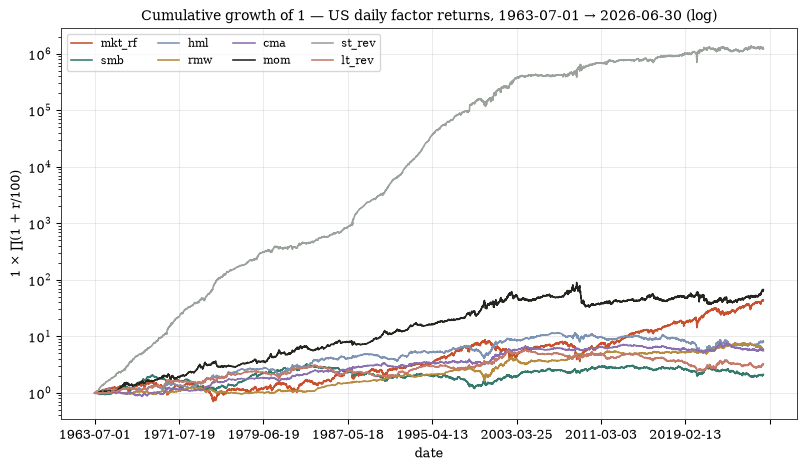

## 13.4 Cumulative return — the 5 Fama-French factors, last 5 years

The five Fama/French factors (`mkt_rf`, `smb`, `hml`, `rmw`, `cma`) over the trailing five years (2021-07-01 → 2026-06-30), compounded daily from the stored percent returns. `Mkt-RF` is the market excess return; the other four are long-short spreads (value-weighted bucket averages minus their counterparts) — the standard cumulative illustration, not a tradable product.

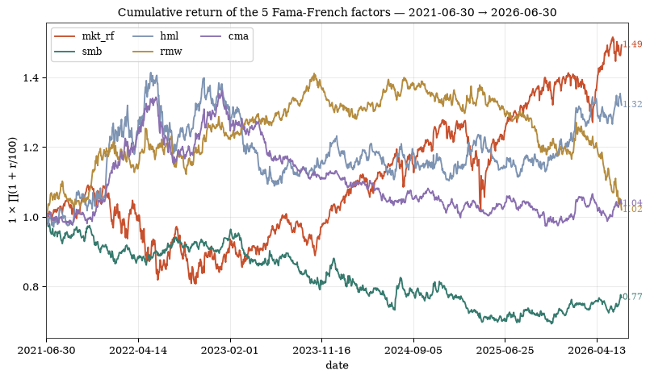

## 13.5 Querying and refresh

```sql
SELECT date, mkt_rf, smb, hml, mom FROM french_factors
WHERE date >= '2000-01-01' AND date <= '2000-12-29';
```

Refresh is fully wired into the pipeline: `data-manager update-french-factors` (manifest-skipped via the site’s Last-Modified header, `--force` to re-download), and every `bulk-update` / `bulk-fromzero` pass refreshes it too. Column definitions live in the in-DB data dictionary (`SELECT * FROM descriptions WHERE table_name = 'french_factors'`).

# Appendix: SF1 indicator dictionary

The complete 112-indicator dictionary, every row shown, grouped by statement family (vendor indicator names). “column” = a native SQLite column — all 112 fields (7 key/date + 105 indicators) are stored as columns in `sf1`.

**Income statement** — 23 indicators

|  | code | indicator | column? |
| --- | --- | --- | --- |
| 0 | revenue | Revenues | column |
| 1 | cor | Cost of Revenue | column |
| 2 | gp | Gross Profit | column |
| 3 | opex | Operating Expenses | column |
| 4 | sgna | Selling General and Administrative Expense | column |
| 5 | rnd | Research and Development Expense | column |
| 6 | opinc | Operating Income | column |
| 7 | ebit | Earning Before Interest & Taxes (EBIT) | column |
| 8 | ebt | Earnings before Tax | column |
| 9 | taxexp | Income Tax Expense | column |
| 10 | netinc | Net Income | column |
| 11 | netincnci | Net Income to Non-Controlling Interests | column |
| 12 | netincdis | Net Loss Income from Discontinued Operations | column |
| 13 | consolinc | Consolidated Income | column |
| 14 | netinccmn | Net Income Common Stock | column |
| 15 | ebitda | Earnings Before Interest Taxes & Depreciation Amortization (EBITDA) | column |
| 16 | prefdivis | Preferred Dividends Income Statement Impact | column |
| 17 | sbcomp | Share Based Compensation | column |
| 18 | deferredrev | Deferred Revenue | column |
| 19 | ebitdausd | Earnings Before Interest Taxes & Depreciation Amortization (USD) | column |
| 20 | ebitusd | Earning Before Interest & Taxes (USD) | column |
| 21 | netinccmnusd | Net Income Common Stock (USD) | column |
| 22 | revenueusd | Revenues (USD) | column |

**Balance sheet** — 33 indicators

|  | code | indicator | column? |
| --- | --- | --- | --- |
| 0 | assets | Total Assets | column |
| 1 | assetsc | Current Assets | column |
| 2 | assetsnc | Assets Non-Current | column |
| 3 | assetsavg | Average Assets | column |
| 4 | cashneq | Cash and Equivalents | column |
| 5 | cashnequsd | Cash and Equivalents (USD) | column |
| 6 | debt | Total Debt | column |
| 7 | debtc | Debt Current | column |
| 8 | debtnc | Debt Non-Current | column |
| 9 | debtusd | Total Debt (USD) | column |
| 10 | deposits | Deposit Liabilities | column |
| 11 | equity | Shareholders Equity Attributable to Parent | column |
| 12 | equityavg | Average Equity | column |
| 13 | equityusd | Shareholders Equity (USD) | column |
| 14 | intangibles | Goodwill and Intangible Assets | column |
| 15 | inventory | Inventory | column |
| 16 | investments | Investments | column |
| 17 | investmentsc | Investments Current | column |
| 18 | investmentsnc | Investments Non-Current | column |
| 19 | liabilities | Total Liabilities | column |
| 20 | liabilitiesc | Current Liabilities | column |
| 21 | liabilitiesnc | Liabilities Non-Current | column |
| 22 | payables | Trade and Non-Trade Payables | column |
| 23 | ppnenet | Property Plant & Equipment Net | column |
| 24 | receivables | Trade and Non-Trade Receivables | column |
| 25 | retearn | Accumulated Retained Earnings (Deficit) | column |
| 26 | taxassets | Tax Assets | column |
| 27 | taxliabilities | Tax Liabilities | column |
| 28 | tangibles | Tangible Asset Value | column |
| 29 | accoci | Accumulated Other Comprehensive Income | column |
| 30 | workingcapital | Working Capital | column |
| 31 | invcap | Invested Capital | column |
| 32 | invcapavg | Invested Capital Average | column |

**Cash flow** — 14 indicators

|  | code | indicator | column? |
| --- | --- | --- | --- |
| 0 | ncfo | Net Cash Flow from Operations | column |
| 1 | ncfi | Net Cash Flow from Investing | column |
| 2 | ncff | Net Cash Flow from Financing | column |
| 3 | ncf | Net Cash Flow / Change in Cash & Cash Equivalents | column |
| 4 | ncfbus | Net Cash Flow - Business Acquisitions and Disposals | column |
| 5 | ncfcommon | Issuance (Purchase) of Equity Shares | column |
| 6 | ncfdebt | Issuance (Repayment) of Debt Securities | column |
| 7 | ncfdiv | Payment of Dividends & Other Cash Distributions | column |
| 8 | ncfinv | Net Cash Flow - Investment Acquisitions and Disposals | column |
| 9 | ncfx | Effect of Exchange Rate Changes on Cash | column |
| 10 | capex | Capital Expenditure | column |
| 11 | fcf | Free Cash Flow | column |
| 12 | depamor | Depreciation Amortization & Accretion | column |
| 13 | intexp | Interest Expense | column |

**Per-share & valuation** — 23 indicators

|  | code | indicator | column? |
| --- | --- | --- | --- |
| 0 | eps | Earnings per Basic Share | column |
| 1 | epsdil | Earnings per Diluted Share | column |
| 2 | epsusd | Earnings per Basic Share (USD) | column |
| 3 | dps | Dividends per Basic Common Share | column |
| 4 | fcfps | Free Cash Flow per Share | column |
| 5 | sps | Sales per Share | column |
| 6 | bvps | Book Value per Share | column |
| 7 | tbvps | Tangible Assets Book Value per Share | column |
| 8 | shareswa | Weighted Average Shares | column |
| 9 | shareswadil | Weighted Average Shares Diluted | column |
| 10 | sharesbas | Shares (Basic) | column |
| 11 | sharefactor | Share Factor | column |
| 12 | marketcap | Market Capitalization | column |
| 13 | ev | Enterprise Value | column |
| 14 | pe | Price Earnings (Damodaran Method) | column |
| 15 | pe1 | Price to Earnings Ratio | column |
| 16 | pb | Price to Book Value | column |
| 17 | ps | Price Sales (Damodaran Method) | column |
| 18 | ps1 | Price to Sales Ratio | column |
| 19 | divyield | Dividend Yield | column |
| 20 | payoutratio | Payout Ratio | column |
| 21 | price | Share Price (Adjusted Close) | column |
| 22 | fxusd | Foreign Currency to USD Exchange Rate | column |

**Margins & efficiency** — 12 indicators

|  | code | indicator | column? |
| --- | --- | --- | --- |
| 0 | grossmargin | Gross Margin | column |
| 1 | netmargin | Profit Margin | column |
| 2 | ebitdamargin | EBITDA Margin | column |
| 3 | ros | Return on Sales | column |
| 4 | roa | Return on Average Assets | column |
| 5 | roe | Return on Average Equity | column |
| 6 | roic | Return on Invested Capital | column |
| 7 | currentratio | Current Ratio | column |
| 8 | de | Debt to Equity Ratio | column |
| 9 | assetturnover | Asset Turnover | column |
| 10 | evebit | Enterprise Value over EBIT | column |
| 11 | evebitda | Enterprise Value over EBITDA | column |